# TP2_IAU2

Felipe Arteaga

2023-09-10

# **ANÁLISIS DE PARIS**

#### **COLEGIOS**

###### **París DATA**

En este segundo ejercicio “TP2” procederé a analizar información relativa a los colegios en la ciudad de París, de modo tal de saber; ¿que barrio es el que contiene la mayor y cual la menos cantidad de colegios? Así como la cantidad promedio y la densidad, entre otros temas.

En primer lugar instalo las librerías que voy a requerir.

```r
library(tidyverse)
library(sf)
```

```r
library(ggplot2)
```

Cargo la información de los diferentes barrios de la ciudad de París descargada de la página de París DATA y corroboro su morfología mapeando los datos.

```r
paris<- st_read("Data/arrondissements.geojson", stringsAsFactors = TRUE)
```

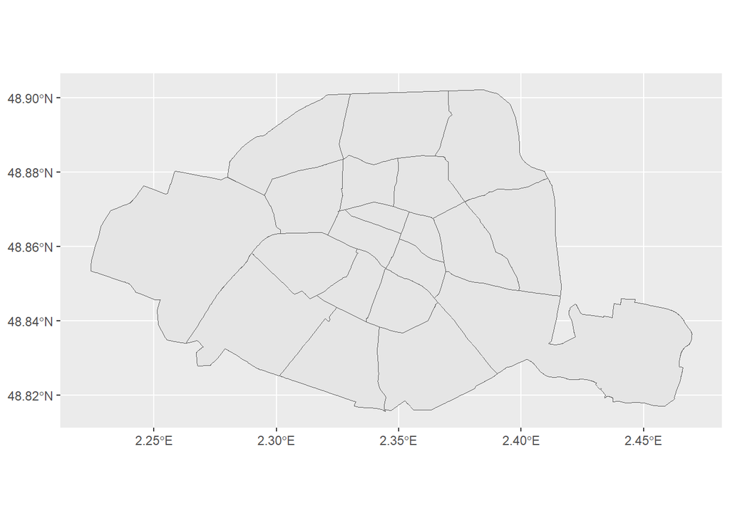

```r
ggplot()+
  geom_sf(data=paris)
```

Con el archivo cargado y corroborado procedo a subir los datos de los establecimientos escolares; colegio. Los mapeo.

```r
colegios<- st_read("Data/etablissements-scolaires-colleges.geojson", stringsAsFactors = TRUE)
names(colegios)
```

```
## [1] "adresse"      "arr_libelle"  "arr_insee"    "id_projet"    "libelle"
## [6] "annee_scol"   "type_etabl"   "geo_point_2d" "geometry"
```

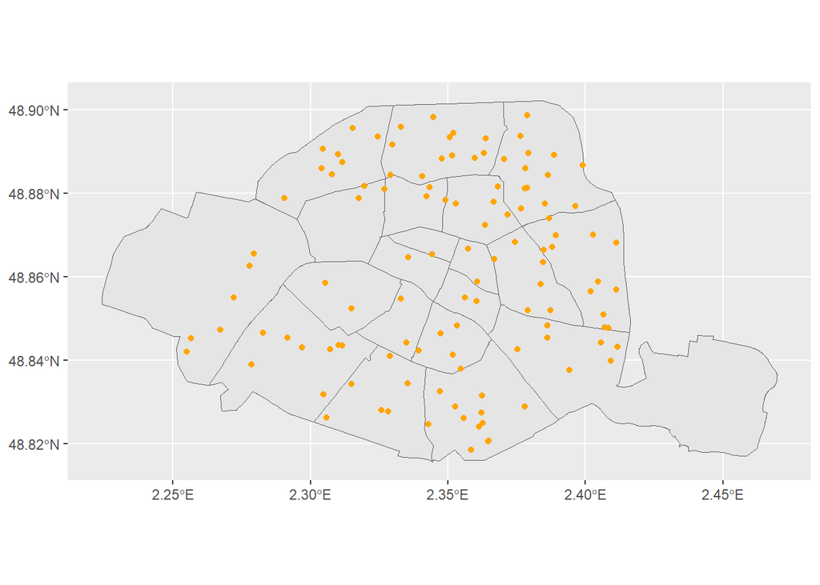

```r
ggplot() +
    geom_sf(data = paris) +
  geom_sf(data = colegios, color = "orange")
```

Transformo el archivo de colegios en uno georeferenciado para poder luego hacer un JOIN espacial.

```r
cole_geo <- colegios %>%
    st_as_sf(coords = c("long", "lat"), crs = 4326)
```

```r
class(cole_geo)
```

```
## [1] "sf"         "data.frame"
```

```r
head(cole_geo)
```

```
## Simple feature collection with 6 features and 8 fields
## Geometry type: POINT
## Dimension:     XY
## Bounding box:  xmin: 2.277839 ymin: 48.84129 xmax: 2.378877 ymax: 48.89861
## Geodetic CRS:  WGS 84
##                      adresse arr_libelle arr_insee
## 1    149 boulevard MacDonald  19ème Ardt     75119
## 2 77 bis BOULEVARD DE CLICHY   9ème Ardt     75109
## 3            14 RUE DE STAEL  15ème Ardt     75115
## 4               88 rue MONGE   5ème Ardt     75105
## 5    13 rue EUGENE DELACROIX  16ème Ardt     75116
## 6              6 rue MOLIERE    1er Ardt     75101
##                                         id_projet                libelle
## 1 COLLEGES (année scolaire 2017/2018 - 2018/2019)         SUZANNE LACORE
## 2 COLLEGES (année scolaire 2017/2018 - 2018/2019)            JULES FERRY
## 3 COLLEGES (année scolaire 2017/2018 - 2018/2019)        MADAME DE STAEL
## 4 COLLEGES (année scolaire 2017/2018 - 2018/2019)         PIERRE ALVISET
## 5 COLLEGES (année scolaire 2017/2018 - 2018/2019)       EUGENE DELACROIX
## 6 COLLEGES (année scolaire 2017/2018 - 2018/2019) JEAN-BAPTISTE POQUELIN
##   annee_scol type_etabl        geo_point_2d                  geometry
## 1       <NA>       <NA> 48.898609, 2.378877 POINT (2.378877 48.89861)
## 2       <NA>       <NA> 48.884350, 2.329146 POINT (2.329146 48.88435)
## 3       <NA>       <NA> 48.843618, 2.310171 POINT (2.310171 48.84362)
## 4       <NA>       <NA> 48.841295, 2.351784 POINT (2.351784 48.84129)
## 5       <NA>       <NA> 48.862606, 2.277839 POINT (2.277839 48.86261)
## 6       <NA>       <NA> 48.864653, 2.335488 POINT (2.335488 48.86465)
```

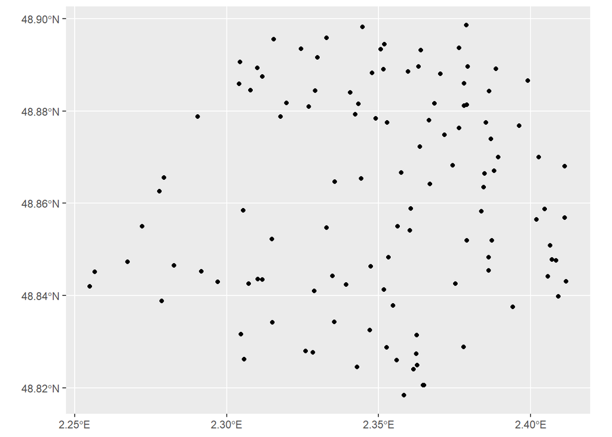

```r
ggplot(cole_geo)+
  geom_sf()
```

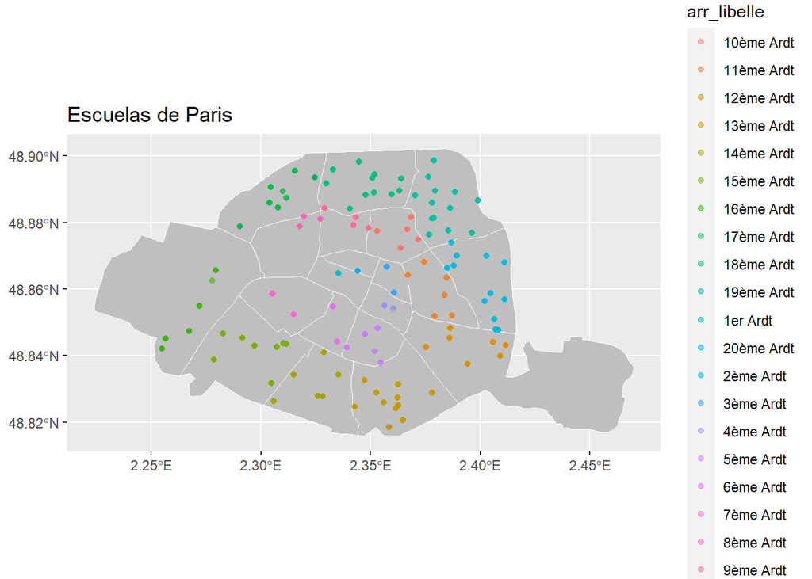

```r
ggplot()+
  geom_sf(data=paris, fill="gray75", color="white")+
  geom_sf(data=cole_geo, aes(color=arr_libelle), alpha=0.5)+
  labs(title="Escuelas de Paris")
```

A continuación realizo el JOIN espacial entre el archivos de barrios y colegios para poder tener la información de barrios dentro de colegios.

```r
cole_geo <- st_join(cole_geo, paris)
```

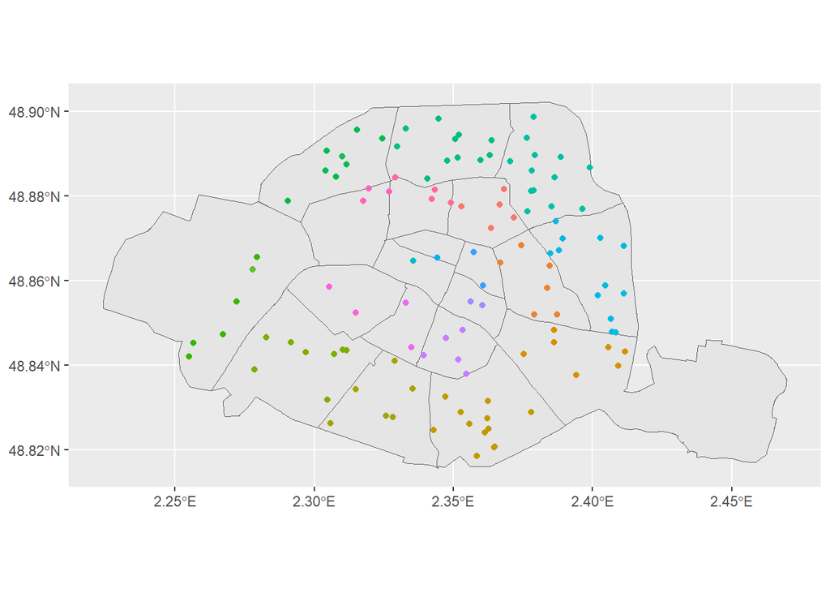

```r
ggplot()+
  geom_sf(data=paris)+
  geom_sf(data=cole_geo, aes(color=arr_libelle), alpha=0.75, show.legend = FALSE)
```

Filtro los valores sin dato.

```r
cole_geo <- cole_geo %>%
  filter(!is.na(arr_libelle))
```

Vuelvo a mapear los barrios y colegios con un color diferente por cada barrio.

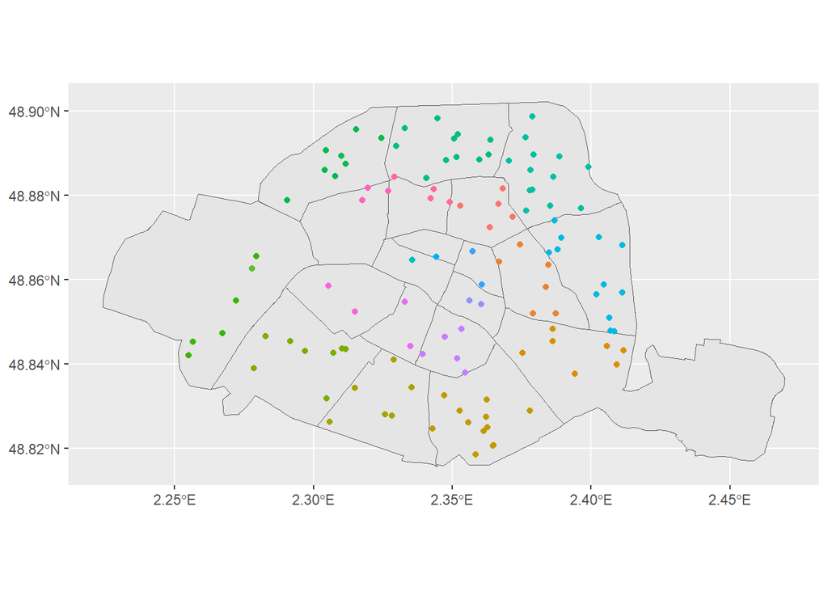

```r
ggplot()+
  geom_sf(data=paris)+
  geom_sf(data=cole_geo, aes(color=arr_libelle), alpha=0.75, show.legend = FALSE)
```

## **PROCESAMIENTO DE DATOS**

Procedo a crear dos columnas/campos nuevos. Uno sobre la cantidad de colegios por barrio y otro de densidad de colegios para lo cual usare la reciente columna creada de cantidad junto a los valores de superficie de cada barrio.

```r
colnames(cole_geo)
```

```
##  [1] "adresse"      "arr_libelle"  "arr_insee"    "id_projet"    "libelle"
##  [6] "annee_scol"   "type_etabl"   "geo_point_2d" "c_ar"         "l_aroff"
## [11] "surface"      "l_ar"         "n_sq_co"      "c_arinsee"    "n_sq_ar"
## [16] "perimetre"    "geom_x_y"     "geometry"
```

```r
cole_geo <- cole_geo %>%
  group_by(l_ar) %>%
  summarise(cantidad=n(),
            densidad_cole=mean(cantidad/surface))
```

Vemos que las columnas se crearon correctamente.

```r
head(cole_geo)
```

```
## Simple feature collection with 6 features and 3 fields
## Geometry type: MULTIPOINT
## Dimension:     XY
## Bounding box:  xmin: 2.27859 ymin: 48.81844 xmax: 2.411708 ymax: 48.88162
## Geodetic CRS:  WGS 84
## # A tibble: 6 × 4
##   l_ar       cantidad densidad_cole                                     geometry
##   <fct>         <int>         <dbl>                             <MULTIPOINT [°]>
## 1 10ème Ardt       25    0.00000865 ((2.371691 48.87485), (2.371691 48.87485), …
## 2 11ème Ardt       30    0.00000818 ((2.374321 48.86823), (2.374321 48.86823), …
## 3 12ème Ardt       35    0.00000215 ((2.386163 48.84831), (2.386163 48.84831), …
## 4 13ème Ardt       55    0.00000769 ((2.358379 48.81844), (2.358379 48.81844), …
## 5 14ème Ardt       30    0.00000534 ((2.314972 48.83426), (2.314972 48.83426), …
## 6 15ème Ardt       40    0.00000471 ((2.27859 48.83886), (2.27859 48.83886), (2…
```

Luego mapeo los datos de densidad de colegios por barrio, sin tener la información volcada sobre los polígonos.

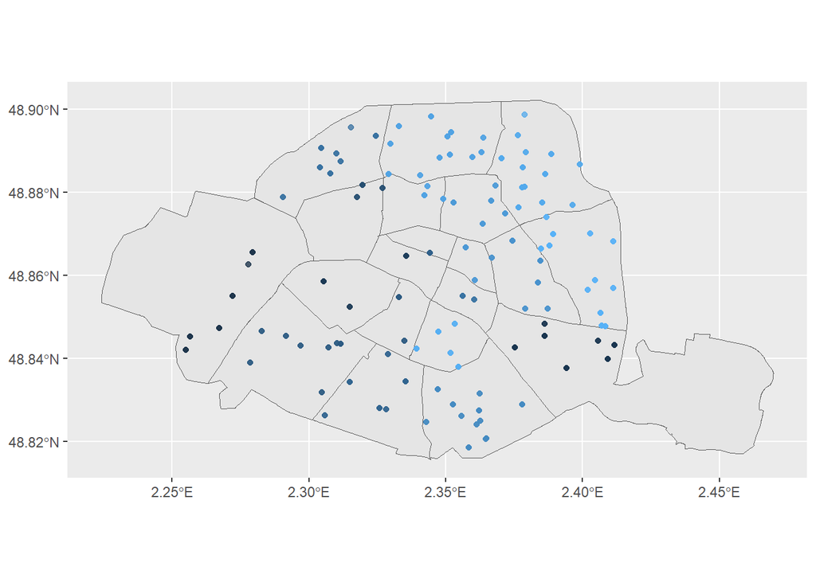

```r
ggplot()+
  geom_sf(data=paris)+
  geom_sf(data=cole_geo, aes(color=densidad_cole), alpha=0.75, show.legend = FALSE)
```

## **TRASPASO DE INFORMACIÓN A POLÍGONOS**

En consecuencia, decido pasar la data a los polígono correspondientes para lo cual tendré que sacarle la geometría al archivo de colegio para poder realizar un LEFT JOIN ya que esta herramienta sólo une archivos espaciales con no espaciales, no así, dos geográficos a la vez.

```r
cole_geo <- cole_geo %>%
  st_set_geometry(NULL)
```

```r
head(cole_geo)
```

```
## # A tibble: 6 × 3
##   l_ar       cantidad densidad_cole
##   <fct>         <int>         <dbl>
## 1 10ème Ardt       25    0.00000865
## 2 11ème Ardt       30    0.00000818
## 3 12ème Ardt       35    0.00000215
## 4 13ème Ardt       55    0.00000769
## 5 14ème Ardt       30    0.00000534
## 6 15ème Ardt       40    0.00000471
```

Se puede apreciar que el archivo se ejecuta correctamente sacando la información geográfica. Ahora realizo el LEFT JOIN y mapeo para verificar que todo haya resultado bien.

```r
paris_b <- left_join(paris, cole_geo, by="l_ar")
```

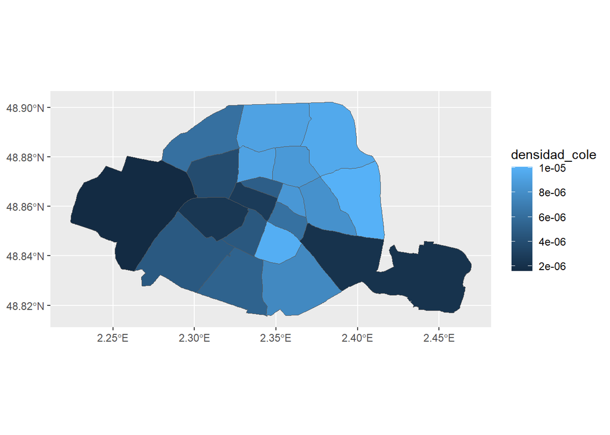

```r
ggplot()+
  geom_sf(data=paris_b, aes(fill=densidad_cole))
```

## **DENSIDAD DE COLEGIOS**

Una vez verificado con el mapa, decido editarlo para presentar los resultados finales.

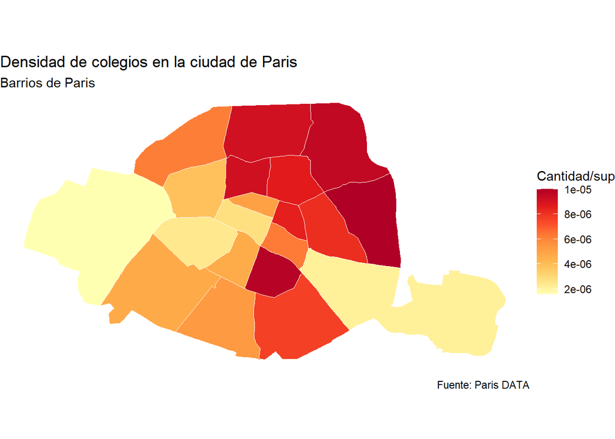

```r
ggplot()+
  geom_sf(data=paris_b, aes(fill=densidad_cole), color="white")+
    labs(title = "Densidad de colegios en la ciudad de Paris",
         subtitle = "Barrios de Paris",
         fill = "Cantidad/sup",
         caption= "Fuente: Paris DATA") +
  scale_fill_distiller(palette = "YlOrRd", direction = 1) +
   theme_void()
```

## **CANTIDAD DE COLEGIOS**

A continuación mostrare la cantidad de colegios por barrio de la ciudad de París con el archivo de Colegios. De esta forma podre analizar cuales son los barrios con mayor cantidad de colegios a través de un gráfico de barras.

[figure not shown]

```r
ggplot(colegios)+
  geom_bar(aes(x=arr_libelle ))+
  coord_flip()+
  labs(title="Cantidad total de colegios por Barrio",
       x="Barrios",
       y="Cantidad",
       caption="Fuente: Paris DATA")+
  theme(legend.position="top",
        legend.direction = "horizontal",
        legend.title=element_text(size=8, face = "bold"),
        legend.text=element_text(size=8),
        axis.text.x = element_text(colour = "gray35",size = 6),
        axis.text.y = element_text(colour = "gray35",size = 1))
```

Finalmente, mapeo esta información con el archivo de polígonos.

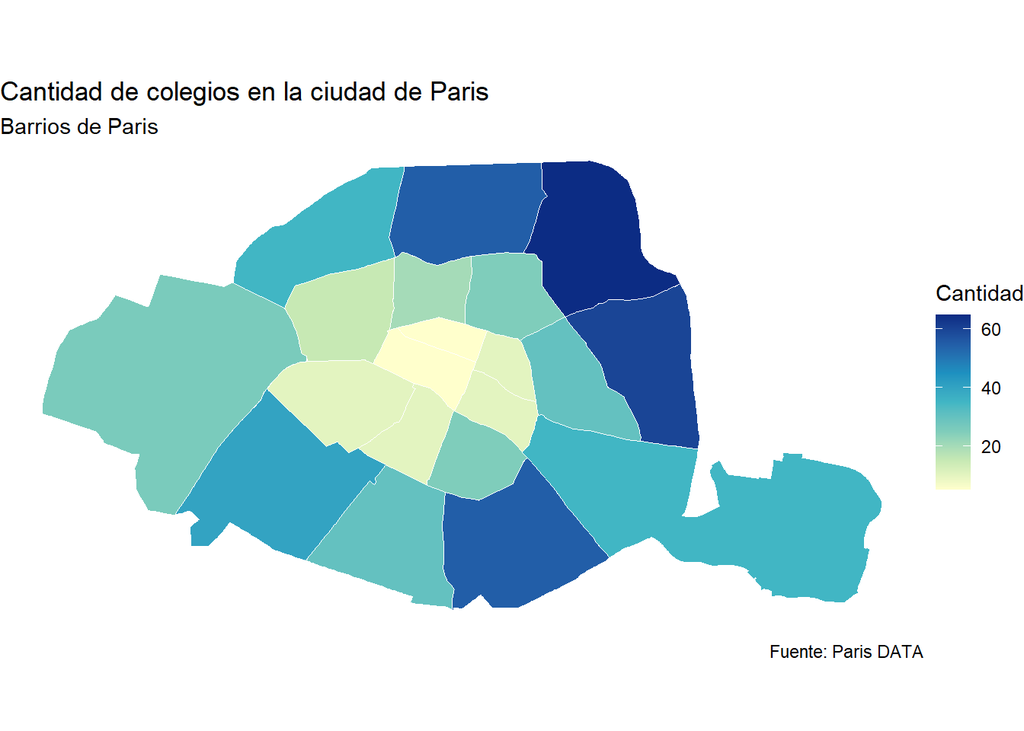

```r
ggplot()+
  geom_sf(data=paris_b, aes(fill=cantidad), color="white")+
    labs(title = "Cantidad de colegios en la ciudad de Paris",
         subtitle = "Barrios de Paris",
         fill = "Cantidad",
         caption= "Fuente: Paris DATA") +
  scale_fill_distiller(palette = "YlGnBu", direction = 1) +
   theme_void()
```

## **CONCLUSIONES**

Decido realizar un resumen estadístico de la información como se puede ver:

```r
summary(paris_b)
```

```
##       c_ar                      l_aroff      surface                 l_ar
##  Min.   : 1.00   Batignolles-Monceau: 1   Min.   :  991154   10ème Ardt: 1
##  1st Qu.: 5.75   Bourse             : 1   1st Qu.: 2172001   11ème Ardt: 1
##  Median :10.50   Buttes-Chaumont    : 1   Median : 3985047   12ème Ardt: 1
##  Mean   :10.50   Buttes-Montmartre  : 1   Mean   : 5268639   13ème Ardt: 1
##  3rd Qu.:15.25   Élysée             : 1   3rd Qu.: 6195201   14ème Ardt: 1
##  Max.   :20.00   Entrepôt           : 1   Max.   :16372542   15ème Ardt: 1
##                  (Other)            :14                      (Other)   :14
##
##
##
##
##
##
##
##
##
##
##
##
##
##     n_sq_co          c_arinsee        n_sq_ar          perimetre
##  Min.   :7.5e+08   Min.   :75101   Min.   :7.5e+08   Min.   : 4519
##  1st Qu.:7.5e+08   1st Qu.:75106   1st Qu.:7.5e+08   1st Qu.: 6413
##  Median :7.5e+08   Median :75111   Median :7.5e+08   Median : 8191
##  Mean   :7.5e+08   Mean   :75111   Mean   :7.5e+08   Mean   : 9522
##  3rd Qu.:7.5e+08   3rd Qu.:75115   3rd Qu.:7.5e+08   3rd Qu.:10895
##  Max.   :7.5e+08   Max.   :75120   Max.   :7.5e+08   Max.   :24090
##
##
##
##
##
##
##
##
##
##
##
##
```

[output cut: 29 more lines]

```
##  Max.   :1.003e-05
##
##
##
##
##
##
##
##
##
##
##
##
##
##
```

Se puede detectar algunos detalles:

- El barrio con mayor cantidad de colegios es el distrito 19 Buttes-Chaumont y tiene 65 establecimientos.
- Los barrios con menor cantidad de colegios son el distrito 1 y 2 (Louvre y Bourse) y ambos tienen 5 establecimientos cada uno.
- La fuente de todas las observaciones eshttps://opendata.paris.fr/pages/home/
- La cantidad promedio es de 28 colegios por barrio.

En base al análisis general decido profundizar más en los 5 barrios con mayor cantidad de colegios:

```r
ordenado <- paris_b %>%

arrange(desc(cantidad))

head(ordenado,5)
```

```
## Simple feature collection with 5 features and 11 fields
## Geometry type: POLYGON
## Dimension:     XY
## Bounding box:  xmin: 2.262959 ymin: 48.81558 xmax: 2.416431 ymax: 48.90216
## Geodetic CRS:  WGS 84
##   c_ar           l_aroff surface       l_ar   n_sq_co c_arinsee   n_sq_ar
## 1   19   Buttes-Chaumont 6792651 19ème Ardt 750001537     75119 750000019
## 2   20      Ménilmontant 5983446 20ème Ardt 750001537     75120 750000020
## 3   18 Buttes-Montmartre 5996051 18ème Ardt 750001537     75118 750000018
## 4   13          Gobelins 7149311 13ème Ardt 750001537     75113 750000013
## 5   15         Vaugirard 8494994 15ème Ardt 750001537     75115 750000015
##   perimetre            geom_x_y cantidad densidad_cole
## 1 11253.182 48.887076, 2.384821       65  9.569165e-06
## 2 10704.940 48.863461, 2.401188       60  1.002767e-05
## 3  9916.464 48.892569, 2.348161       55  9.172703e-06
## 4 11546.547 48.828388, 2.362272       55  7.693049e-06
## 5 13678.798 48.840085, 2.292826       40  4.708655e-06
##                         geometry
## 1 POLYGON ((2.389428 48.90122...
## 2 POLYGON ((2.412765 48.87547...
## 3 POLYGON ((2.365804 48.88554...
## 4 POLYGON ((2.374913 48.83801...
## 5 POLYGON ((2.299322 48.85217...
```

1. **Buttes-Chaumont**
2. **Ménilmontant**
3. **Buttes-Montmartre**
4. Gobelins
5. Vaugirard

Por otro lado, los 5 barrios con más densidad de colegios son:

```r
ordenado_b <- paris_b %>%

arrange(desc(densidad_cole))

head(ordenado_b,5)
```

```
## Simple feature collection with 5 features and 11 fields
## Geometry type: POLYGON
## Dimension:     XY
## Bounding box:  xmin: 2.32559 ymin: 48.83678 xmax: 2.416431 ymax: 48.90216
## Geodetic CRS:  WGS 84
##   c_ar           l_aroff surface       l_ar   n_sq_co c_arinsee   n_sq_ar
## 1   20      Ménilmontant 5983446 20ème Ardt 750001537     75120 750000020
## 2    5          Panthéon 2539375  5ème Ardt 750001537     75105 750000005
## 3   19   Buttes-Chaumont 6792651 19ème Ardt 750001537     75119 750000019
## 4    9             Opéra 2178303  9ème Ardt 750001537     75109 750000009
## 5   18 Buttes-Montmartre 5996051 18ème Ardt 750001537     75118 750000018
##   perimetre            geom_x_y cantidad densidad_cole
## 1 10704.940 48.863461, 2.401188       60  1.002767e-05
## 2  6239.195 48.844443, 2.350715       25  9.844944e-06
## 3 11253.182 48.887076, 2.384821       65  9.569165e-06
## 4  6471.588 48.877164, 2.337458       20  9.181458e-06
## 5  9916.464 48.892569, 2.348161       55  9.172703e-06
##                         geometry
## 1 POLYGON ((2.412765 48.87547...
## 2 POLYGON ((2.364433 48.84614...
## 3 POLYGON ((2.389428 48.90122...
## 4 POLYGON ((2.339777 48.88203...
## 5 POLYGON ((2.365804 48.88554...
```

1. **Ménilmontant**
2. **Panthéon**
3. **Buttes-Chaumont**
4. Opéra
5. Buttes-Montmartre